# Study 1: Reinforcement-Punishment Analysis

## Model 2 (Saltwater vs Neutral):

The second model whether monetary reward effects are present with saltwater and neutral liquids. the GLMM reveals a significant effect of money and significant effect of liquid, but no interaction. Post hoc analyes reveal that omitting low reward trials result in stronger significant effect of money, and a significant liquid effect. Omitting medium reward trials maintains significant monetary reward effect, but the liquid effect is weaker. Omitting high reward trials eradicate the monetary reward effects but keep the liquid effects. Thus, for low and medium monetary reward values, we see a boost in punishment avoidance based on liquid type, but no significant differences between low and monetary reward rates.

```r
# Liquid Effect: Salt vs Neutral
m.RR.1.SvN<-glmer(formula = subRewarded ~ moneyCode*liqCode + (1+liqCode|subID),
          data = subset(incentive,liqCode!=1), family=binomial)
summary(m.RR.1.SvN)
```

```
## Generalized linear mixed model fit by maximum likelihood (Laplace
##   Approximation) [glmerMod]
##  Family: binomial  ( logit )
## Formula: subRewarded ~ moneyCode * liqCode + (1 + liqCode | subID)
##    Data: subset(incentive, liqCode != 1)
##
##      AIC      BIC   logLik deviance df.resid
##   8758.0   8806.4  -4372.0   8744.0     7481
##
## Scaled residuals:
##     Min      1Q  Median      3Q     Max
## -3.2201 -1.0819  0.5002  0.6952  1.2481
##
## Random effects:
##  Groups Name        Variance Std.Dev. Corr
##  subID  (Intercept) 0.39694  0.6300
##         liqCode     0.05346  0.2312   0.03
## Number of obs: 7488, groups:  subID, 39
##
## Fixed effects:
##                   Estimate Std. Error z value Pr(>|z|)
## (Intercept)        0.83918    0.10771   7.791 6.63e-15 ***
## moneyCode          0.08960    0.04459   2.009   0.0445 *
## liqCode           -0.14615    0.06578  -2.222   0.0263 *
## moneyCode:liqCode -0.03432    0.06394  -0.537   0.5914
## ---
## Signif. codes:  0 '***' 0.001 '**' 0.01 '*' 0.05 '.' 0.1 ' ' 1
##
## Correlation of Fixed Effects:
##             (Intr) monyCd liqCod
## moneyCode   0.009
## liqCode     0.214  0.015
## monyCd:lqCd 0.006  0.697  0.028
```

```r
m.RR.1.SvN.omitrew1<-glmer(formula = subRewarded ~ moneyCode*liqCode + (1+liqCode|subID),
          data = subset(incentive,liqCode!=1 & moneyCode!=-1), family=binomial)
summary(m.RR.1.SvN.omitrew1)
```

```
## Generalized linear mixed model fit by maximum likelihood (Laplace
##   Approximation) [glmerMod]
##  Family: binomial  ( logit )
## Formula: subRewarded ~ moneyCode * liqCode + (1 + liqCode | subID)
##    Data: subset(incentive, liqCode != 1 & moneyCode != -1)
##
##      AIC      BIC   logLik deviance df.resid
##   5768.5   5814.1  -2877.2   5754.5     4985
##
## Scaled residuals:
##     Min      1Q  Median      3Q     Max
## -3.5383 -1.0528  0.4848  0.6751  1.3140
##
## Random effects:
##  Groups Name        Variance Std.Dev. Corr
##  subID  (Intercept) 0.4581   0.6768
##         liqCode     0.1008   0.3175   0.12
## Number of obs: 4992, groups:  subID, 39
##
## Fixed effects:
##                   Estimate Std. Error z value Pr(>|z|)
## (Intercept)        0.74896    0.12564   5.961  2.5e-09 ***
## moneyCode          0.24322    0.09001   2.702  0.00689 **
## liqCode           -0.21992    0.10507  -2.093  0.03634 *
## moneyCode:liqCode  0.07460    0.12932   0.577  0.56404
## ---
## Signif. codes:  0 '***' 0.001 '**' 0.01 '*' 0.05 '.' 0.1 ' ' 1
##
## Correlation of Fixed Effects:
##             (Intr) monyCd liqCod
## moneyCode   -0.342
## liqCode      0.357 -0.409
## monyCd:lqCd -0.238  0.696 -0.590
```

```r
m.RR.1.SvN.omitrew2<-glmer(formula = subRewarded ~ moneyCode*liqCode + (1+liqCode|subID),
          data = subset(incentive,liqCode!=1 & moneyCode!=0), family=binomial)
summary(m.RR.1.SvN.omitrew2)
```

```
## Generalized linear mixed model fit by maximum likelihood (Laplace
##   Approximation) [glmerMod]
##  Family: binomial  ( logit )
## Formula: subRewarded ~ moneyCode * liqCode + (1 + liqCode | subID)
##    Data: subset(incentive, liqCode != 1 & moneyCode != 0)
##
##      AIC      BIC   logLik deviance df.resid
##   5859.4   5905.0  -2922.7   5845.4     4985
##
## Scaled residuals:
##     Min      1Q  Median      3Q     Max
## -3.1607 -1.1038  0.5240  0.6737  1.0795
##
## Random effects:
##  Groups Name        Variance Std.Dev. Corr
##  subID  (Intercept) 0.315569 0.56176
##         liqCode     0.002614 0.05113  -1.00
## Number of obs: 4992, groups:  subID, 39
##
## Fixed effects:
##                   Estimate Std. Error z value Pr(>|z|)
## (Intercept)        0.87506    0.10105   8.659   <2e-16 ***
## moneyCode          0.08983    0.04466   2.011   0.0443 *
## liqCode           -0.11103    0.06665  -1.666   0.0958 .
## moneyCode:liqCode -0.03339    0.06391  -0.522   0.6013
## ---
## Signif. codes:  0 '***' 0.001 '**' 0.01 '*' 0.05 '.' 0.1 ' ' 1
##
## Correlation of Fixed Effects:
##             (Intr) monyCd liqCod
## moneyCode   0.015
## liqCode     0.204  0.024
## monyCd:lqCd 0.011  0.699  0.043
```

```r
m.RR.1.SvN.omitrew4<-glmer(formula = subRewarded ~ moneyCode*liqCode + (1+liqCode|subID),
          data = subset(incentive,liqCode!=1 & moneyCode!=1), family=binomial)
summary(m.RR.1.SvN.omitrew4)
```

```
## Generalized linear mixed model fit by maximum likelihood (Laplace
##   Approximation) [glmerMod]
##  Family: binomial  ( logit )
## Formula: subRewarded ~ moneyCode * liqCode + (1 + liqCode | subID)
##    Data: subset(incentive, liqCode != 1 & moneyCode != 1)
##
##      AIC      BIC   logLik deviance df.resid
##   5955.1   6000.7  -2970.6   5941.1     4985
##
## Scaled residuals:
##     Min      1Q  Median      3Q     Max
## -2.9838 -1.0739  0.4955  0.7068  1.2931
##
## Random effects:
##  Groups Name        Variance Std.Dev. Corr
##  subID  (Intercept) 0.42429  0.6514
##         liqCode     0.09798  0.3130   0.16
## Number of obs: 4992, groups:  subID, 39
##
## Fixed effects:
##                   Estimate Std. Error z value Pr(>|z|)
## (Intercept)        0.74389    0.12197   6.099 1.07e-09 ***
## moneyCode         -0.05884    0.08840  -0.666   0.5056
## liqCode           -0.21419    0.10417  -2.056   0.0398 *
## moneyCode:liqCode -0.14121    0.12656  -1.116   0.2645
## ---
## Signif. codes:  0 '***' 0.001 '**' 0.01 '*' 0.05 '.' 0.1 ' ' 1
##
## Correlation of Fixed Effects:
##             (Intr) monyCd liqCod
## moneyCode   0.359
## liqCode     0.380  0.420
## monyCd:lqCd 0.250  0.698  0.610
```

# Error Comission Rate

## Plot: mean error rate by monetary reward level

```r
ERR.sum=summarySEwithin2(data=rew.means, measurevar = "meanERR", withinvars = c("money"),
                        idvar = "subID")
pandoc.table(ERR.sum)
```

```
##
## ----------------------------------------------------------------------
##  money   N    meanERR   meanERRNormed     sd         se         ci
## ------- ---- --------- --------------- --------- ---------- ----------
##    $     39   0.1581       0.1581       0.03351   0.005365   0.01086
##
##   $$     39    0.148        0.148       0.02785   0.004459   0.009027
##
##  $$$$    39   0.1368       0.1368       0.02937   0.004703   0.00952
## ----------------------------------------------------------------------
```

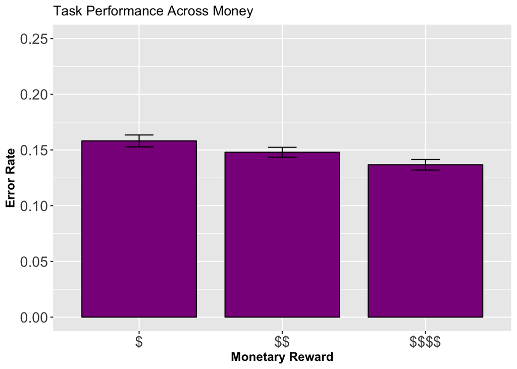

```r
p.ERR.2<-ggplot(ERR.sum, aes(x=money, y=meanERR)) +
  geom_bar(position=position_dodge(width=0.8), color="black",
           fill='darkmagenta', stat="identity", width=0.8) +
  geom_errorbar(position=position_dodge(width=0.8),
                aes(ymin=meanERR-se, ymax=meanERR+se), width=.2) +
  xlab("Monetary Reward") + ylab("Error Rate") +
  ggtitle("Task Performance Across Money") +
  coord_cartesian(ylim=c(0,.25)) +
  scale_fill_discrete(name="Monetary Reward") +
  theme(#plot.title=element_text(size=22,face="bold", vjust=2),
        axis.title=element_text(size=12,face = "bold"),
        axis.text=element_text(size=14),
        legend.position="none",
        strip.text.x = element_text(size = 12))
p.ERR.2
```

## Plot: mean error rate by liquid

```r
ERR.sum=summarySEwithin2(data=liq.means, measurevar = "meanERR", withinvars = c("liquid"),
                        idvar = "subID")
pandoc.table(ERR.sum)
```

```
##
## -------------------------------------------------------------------------
##   liquid     N    meanERR   meanERRNormed     sd         se        ci
## ----------- ---- --------- --------------- --------- ---------- ---------
##    juice     39   0.1504       0.1504       0.03798   0.006081   0.01231
##
##   neutral    39   0.1474       0.1474       0.04502   0.007208   0.01459
##
##  saltwater   39    0.145        0.145       0.05085   0.008143   0.01648
## -------------------------------------------------------------------------
```

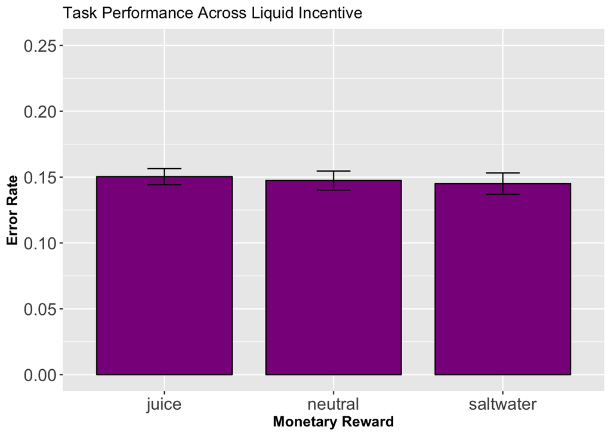

```r
p.ERR.2<-ggplot(ERR.sum, aes(x=liquid, y=meanERR)) +
  geom_bar(position=position_dodge(width=0.8), color="black",
           fill='darkmagenta', stat="identity", width=0.8) +
  geom_errorbar(position=position_dodge(width=0.8),
                aes(ymin=meanERR-se, ymax=meanERR+se), width=.2) +
  xlab("Monetary Reward") + ylab("Error Rate") +
  ggtitle("Task Performance Across Liquid Incentive") +
  coord_cartesian(ylim=c(0,.25)) +
  scale_fill_discrete(name="Monetary Reward") +
  theme(#plot.title=element_text(size=22,face="bold", vjust=2),
        axis.title=element_text(size=12,face = "bold"),
        axis.text=element_text(size=14),
        legend.position="none",
        strip.text.x = element_text(size = 12))
p.ERR.2
```

# Response Times

## Plot: mean response time by monetary reward level

```r
RT.sum=summarySEwithin2(data=rewRT.means, measurevar = "meanRT", withinvars = c("money"),
                        idvar = "subID")
pandoc.table(RT.sum)
```

```
##
## ------------------------------------------------------------
##  money   N    meanRT   meanRTNormed    sd      se      ci
## ------- ---- -------- -------------- ------- ------- -------
##    $     39   521.5       521.5       17.96   2.876   5.821
##
##   $$     39   526.9       526.9       17.95   2.874   5.818
##
##  $$$$    39   503.6       503.6       18.93   3.032   6.137
## ------------------------------------------------------------
```

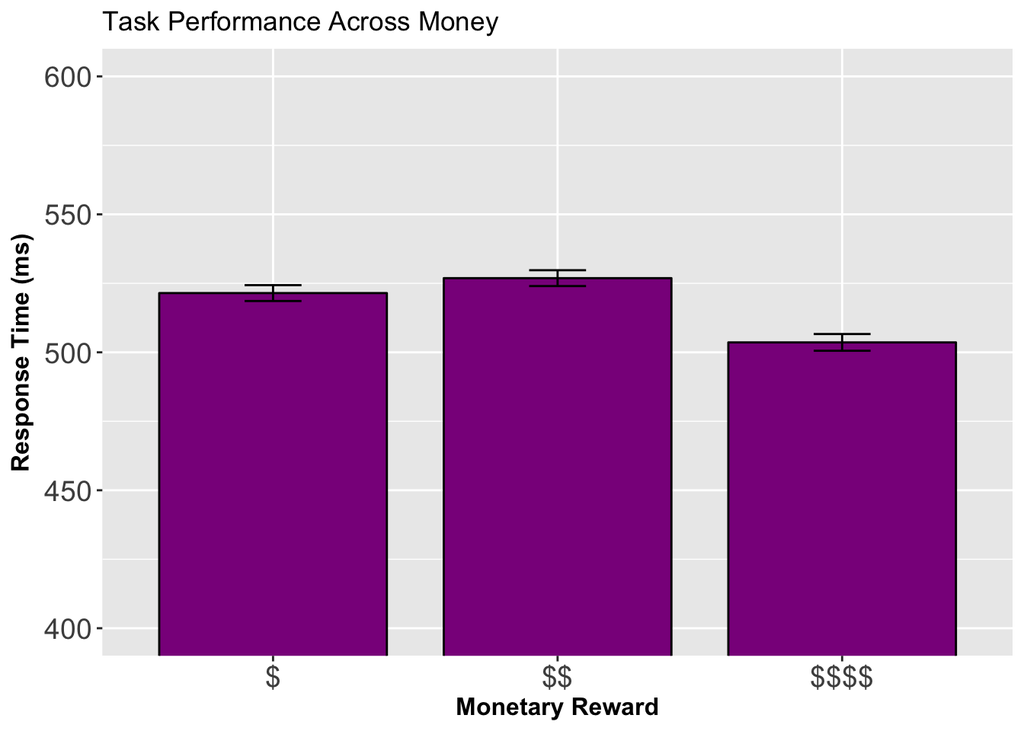

```r
p.RT.1<-ggplot(RT.sum, aes(x=money, y=meanRT)) +
  geom_bar(position=position_dodge(width=0.8), color="black",
           fill='darkmagenta', stat="identity", width=0.8) +
  geom_errorbar(position=position_dodge(width=0.8),
                aes(ymin=meanRT-se, ymax=meanRT+se), width=.2) +
  xlab("Monetary Reward") + ylab("Response Time (ms)") +
  ggtitle("Task Performance Across Money") +
  coord_cartesian(ylim=c(400,600)) +
  scale_fill_discrete(name="Monetary Reward") +
  theme(#plot.title=element_text(size=22,face="bold", vjust=2),
        axis.title=element_text(size=12,face = "bold"),
        axis.text=element_text(size=14),
        legend.position="none",
        strip.text.x = element_text(size = 12))
p.RT.1
```

## Plot: mean response time by liquid

```r
RT.sum=summarySEwithin2(data=liqRT.means, measurevar = "meanRT", withinvars = c("liquid"),
                        idvar = "subID")
pandoc.table(RT.sum)
```

```
##
## ----------------------------------------------------------------
##   liquid     N    meanRT   meanRTNormed    sd      se      ci
## ----------- ---- -------- -------------- ------- ------- -------
##    juice     39   522.1       522.1       36.69   5.875   11.89
##
##   neutral    39   520.2       520.2       41.67   6.673   13.51
##
##  saltwater   39    508         508        37.24   5.963   12.07
## ----------------------------------------------------------------
```

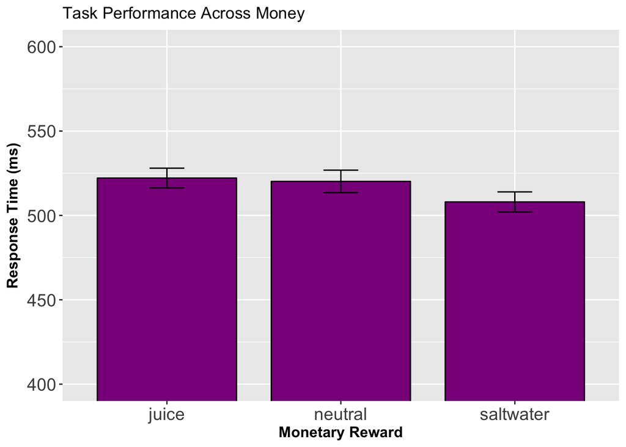

```r
p.RT.2<-ggplot(RT.sum, aes(x=liquid, y=meanRT)) +
  geom_bar(position=position_dodge(width=0.8), color="black",
           fill='darkmagenta', stat="identity", width=0.8) +
  geom_errorbar(position=position_dodge(width=0.8),
                aes(ymin=meanRT-se, ymax=meanRT+se), width=.2) +
  xlab("Monetary Reward") + ylab("Response Time (ms)") +
  ggtitle("Task Performance Across Money") +
  coord_cartesian(ylim=c(400,600)) +
  scale_fill_discrete(name="Monetary Reward") +
  theme(#plot.title=element_text(size=22,face="bold", vjust=2),
        axis.title=element_text(size=12,face = "bold"),
        axis.text=element_text(size=14),
        legend.position="none",
        strip.text.x = element_text(size = 12))
p.RT.2
```

## Plot: mean response time by money and liquid

```r
RT.sum=summarySEwithin2(data=incentive9RT.means, measurevar = "meanRT", withinvars = c("money","liquid"),
                        idvar = "subID")
pandoc.table(RT.sum)
```

```
##
## ------------------------------------------------------------------------
##  money    liquid     N    meanRT   meanRTNormed    sd      se      ci
## ------- ----------- ---- -------- -------------- ------- ------- -------
##    $       juice     39    528         528        42.23   6.762   13.69
##
##    $      neutral    39   522.7       522.7       43.57   6.977   14.12
##
##    $     saltwater   39   511.9       511.9       33.33   5.337   10.8
##
##   $$       juice     39   529.9       529.9       47.19   7.557   15.3
##
##   $$      neutral    39   534.6       534.6       60.86   9.746   19.73
##
##   $$     saltwater   39   514.8       514.8       42.95   6.878   13.92
##
##  $$$$      juice     39   509.3       509.3       35.83   5.737   11.61
##
##  $$$$     neutral    39   503.4       503.4       29.52   4.726   9.568
##
##  $$$$    saltwater   39    498         498        42.36   6.783   13.73
## ------------------------------------------------------------------------
```

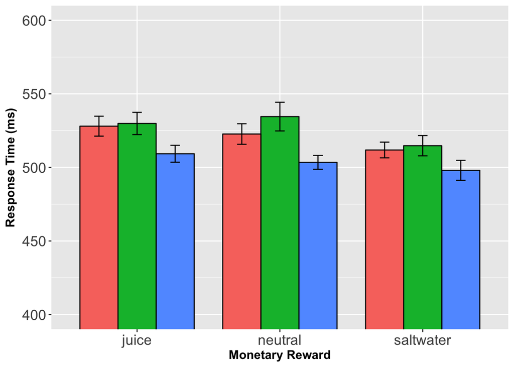

```r
p.RT.3<-ggplot(RT.sum, aes(x=liquid, y=meanRT, fill=money)) +
  geom_bar(position=position_dodge(width=0.8), color="black",
          stat="identity", width=0.8) +
  geom_errorbar(position=position_dodge(width=0.8),
                aes(ymin=meanRT-se, ymax=meanRT+se), width=.2) +
  xlab("Monetary Reward") + ylab("Response Time (ms)") +
  #ggtitle("Response Time (ms)") +
  coord_cartesian(ylim=c(400,600)) +
  scale_fill_discrete(name="Monetary Reward") +
  theme(#plot.title=element_text(size=22,face="bold", vjust=2),
        axis.title=element_text(size=12,face = "bold"),
        axis.text=element_text(size=14),
        legend.position="none",
        strip.text.x = element_text(size = 12))
p.RT.3
```

## GLM RT

Running a general linear model on the response time reveal a significant effect of monetary reward (no surprise), and a marginal effect of liquid. RT appears to be slightly faster in the saltwater condition, and it appears that the presence of saltwater increase motivation in the low and medium reward value trials, whereas the motivational vigor is more disparate with the other liquids.

```r
# omnibus model: reward rate by liquid and money
incentive.RT<-filter(incentive, ACC==1)
m.RT.1<-lmer(formula = RT ~ moneyCode*liqCode + (1+moneyCode+liqCode|subID),
              data = incentive.RT,REML=FALSE)
summary(m.RT.1)
```

```
## Linear mixed model fit by maximum likelihood t-tests use Satterthwaite
##   approximations to degrees of freedom [lmerMod]
## Formula: RT ~ moneyCode * liqCode + (1 + moneyCode + liqCode | subID)
##    Data: incentive.RT
##
##      AIC      BIC   logLik deviance df.resid
## 123087.5 123166.4 -61532.8 123065.5     9563
##
## Scaled residuals:
##     Min      1Q  Median      3Q     Max
## -2.5036 -0.5737 -0.1775  0.3287  9.2812
##
## Random effects:
##  Groups   Name        Variance Std.Dev. Corr
##  subID    (Intercept)  7506.73  86.64
##           moneyCode      35.76   5.98   -0.42
##           liqCode       476.31  21.82    0.25 -0.24
##  Residual             21837.58 147.78
## Number of obs: 9574, groups:  subID, 39
##
## Fixed effects:
##                   Estimate Std. Error       df t value Pr(>|t|)
## (Intercept)        517.211     13.956   39.000  37.059  < 2e-16 ***
## moneyCode           -8.549      2.085   38.000  -4.101 0.000207 ***
## liqCode              6.959      3.957   39.000   1.758 0.086465 .
## moneyCode:liqCode   -1.025      2.268 9488.000  -0.452 0.651309
## ---
## Signif. codes:  0 '***' 0.001 '**' 0.01 '*' 0.05 '.' 0.1 ' ' 1
##
## Correlation of Fixed Effects:
##             (Intr) monyCd liqCod
## moneyCode   -0.195
## liqCode      0.217 -0.099
## monyCd:lqCd  0.000  0.004 -0.006
```

# Accuracy

## Plot: Accuracy by monetary reward level

```r
ACC.sum=summarySEwithin2(data=rew.means, measurevar = "meanACC",
                         withinvars = c("money"),
                        idvar = "subID")
pandoc.table(ACC.sum)
```

```
##
## ----------------------------------------------------------------------
##  money   N    meanACC   meanACCNormed     sd         se         ci
## ------- ---- --------- --------------- --------- ---------- ----------
##    $     39   0.8419       0.8419       0.03351   0.005365   0.01086
##
##   $$     39    0.852        0.852       0.02785   0.004459   0.009027
##
##  $$$$    39   0.8632       0.8632       0.02937   0.004703   0.00952
## ----------------------------------------------------------------------
```

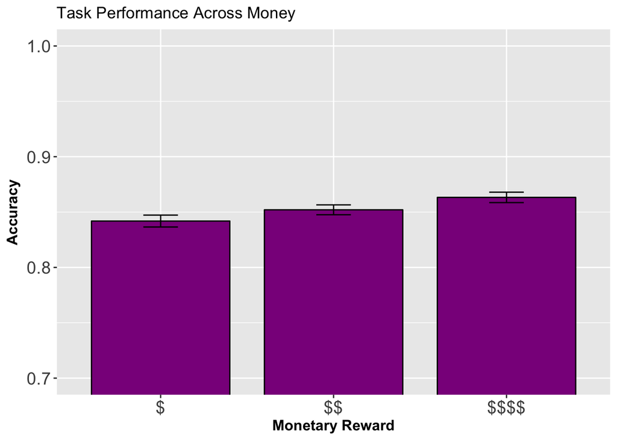

```r
p.ACC.1<-ggplot(ACC.sum, aes(x=money, y=meanACC)) +
  geom_bar(position=position_dodge(width=0.8), color="black",
           fill='darkmagenta', stat="identity", width=0.8) +
  geom_errorbar(position=position_dodge(width=0.8),
                aes(ymin=meanACC-se, ymax=meanACC+se), width=.2) +
  xlab("Monetary Reward") + ylab("Accuracy") +
  ggtitle("Task Performance Across Money") +
  coord_cartesian(ylim=c(.7,1)) +
  scale_fill_discrete(name="Monetary Reward") +
  theme(#plot.title=element_text(size=22,face="bold", vjust=2),
        axis.title=element_text(size=12,face = "bold"),
        axis.text=element_text(size=14),
        legend.position="none",
        strip.text.x = element_text(size = 12))
p.ACC.1
```

## Plot: Accuracy by liquid

```r
ACC.sum=summarySEwithin2(data=liq.means, measurevar = "meanACC",
                        withinvars = c("liquid"),
                        idvar = "subID")
pandoc.table(ACC.sum)
```

```
##
## -------------------------------------------------------------------------
##   liquid     N    meanACC   meanACCNormed     sd         se        ci
## ----------- ---- --------- --------------- --------- ---------- ---------
##    juice     39   0.8496       0.8496       0.03798   0.006081   0.01231
##
##   neutral    39   0.8526       0.8526       0.04502   0.007208   0.01459
##
##  saltwater   39    0.855        0.855       0.05085   0.008143   0.01648
## -------------------------------------------------------------------------
```

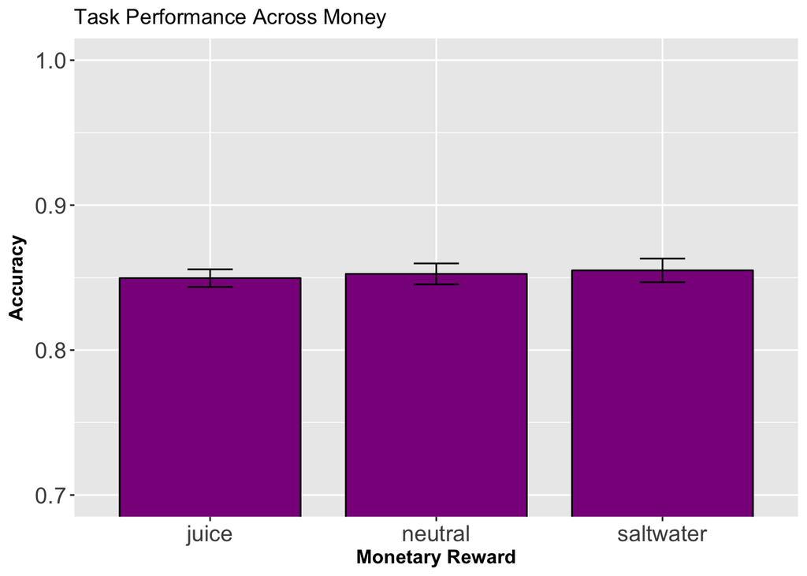

```r
p.ACC.2<-ggplot(ACC.sum, aes(x=liquid, y=meanACC)) +
  geom_bar(position=position_dodge(width=0.8), color="black",
           fill='darkmagenta', stat="identity", width=0.8) +
  geom_errorbar(position=position_dodge(width=0.8),
                aes(ymin=meanACC-se, ymax=meanACC+se), width=.2) +
  xlab("Monetary Reward") + ylab("Accuracy") +
  ggtitle("Task Performance Across Money") +
  coord_cartesian(ylim=c(.7,1)) +
  scale_fill_discrete(name="Monetary Reward") +
  theme(#plot.title=element_text(size=22,face="bold", vjust=2),
        axis.title=element_text(size=12,face = "bold"),
        axis.text=element_text(size=14),
        legend.position="none",
        strip.text.x = element_text(size = 12))
p.ACC.2
```

## Plot: Accuracy by money and liquid

```r
ACC.sum=summarySEwithin2(data=incentive9.means, measurevar = "meanACC",
                        withinvars = c("money","liquid"),
                        idvar = "subID")
pandoc.table(ACC.sum)
```

```
##
## ---------------------------------------------------------------------------------
##  money    liquid     N    meanACC   meanACCNormed     sd         se        ci
## ------- ----------- ---- --------- --------------- --------- ---------- ---------
##    $       juice     39   0.8293       0.8293       0.05175   0.008287   0.01678
##
##    $      neutral    39    0.851        0.851       0.06588   0.01055    0.02136
##
##    $     saltwater   39   0.8454       0.8454       0.06799   0.01089    0.02204
##
##   $$       juice     39   0.8566       0.8566       0.0733    0.01174    0.02376
##
##   $$      neutral    39   0.8478       0.8478       0.05484   0.008781   0.01778
##
##   $$     saltwater   39   0.8518       0.8518       0.0718     0.0115    0.02327
##
##  $$$$      juice     39    0.863        0.863       0.05781   0.009257   0.01874
##
##  $$$$     neutral    39    0.859        0.859       0.05401   0.008649   0.01751
##
##  $$$$    saltwater   39   0.8678       0.8678       0.06371    0.0102    0.02065
## ---------------------------------------------------------------------------------
```

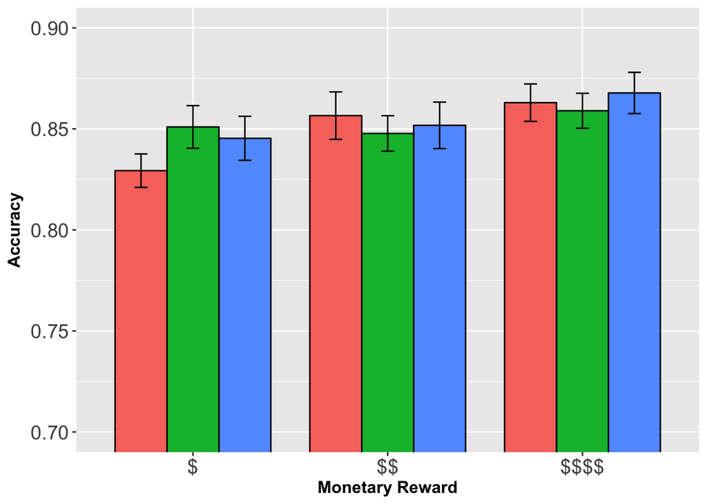

```r
p.RT.3<-ggplot(ACC.sum, aes(x=money, y=meanACC, fill=liquid)) +
  geom_bar(position=position_dodge(width=0.8), color="black",
          stat="identity", width=0.8) +
  geom_errorbar(position=position_dodge(width=0.8),
                aes(ymin=meanACC-se, ymax=meanACC+se), width=.2) +
  xlab("Monetary Reward") + ylab("Accuracy") +
  #ggtitle("Response Time (ms)") +
  coord_cartesian(ylim=c(.7,.9)) +
  scale_fill_discrete(name="Monetary Reward") +
  theme(#plot.title=element_text(size=22,face="bold", vjust=2),
        axis.title=element_text(size=12,face = "bold"),
        axis.text=element_text(size=14),
        legend.position="none",
        strip.text.x = element_text(size = 12))
p.RT.3
```

## GLM Accuracy

```r
# omnibus model: reward rate by liquid and money
m.ACC.1<-glmer(formula = ACC ~ moneyCode*liqCode + (1+moneyCode+liqCode|subID),
              data = incentive, family = binomial)
summary(m.ACC.1)
```

```
## Generalized linear mixed model fit by maximum likelihood (Laplace
##   Approximation) [glmerMod]
##  Family: binomial  ( logit )
## Formula: ACC ~ moneyCode * liqCode + (1 + moneyCode + liqCode | subID)
##    Data: incentive
##
##      AIC      BIC   logLik deviance df.resid
##   9063.2   9136.5  -4521.6   9043.2    11222
##
## Scaled residuals:
##     Min      1Q  Median      3Q     Max
## -6.7019  0.2568  0.3692  0.4592  0.6682
##
## Random effects:
##  Groups Name        Variance Std.Dev. Corr
##  subID  (Intercept) 0.414468 0.64379
##         moneyCode   0.002658 0.05155  0.99
##         liqCode     0.026632 0.16319  0.44 0.59
## Number of obs: 11232, groups:  subID, 39
##
## Fixed effects:
##                   Estimate Std. Error z value Pr(>|z|)
## (Intercept)       1.894911   0.107599  17.611  < 2e-16 ***
## moneyCode         0.108155   0.037739   2.866  0.00416 **
## liqCode           0.006005   0.045504   0.132  0.89500
## moneyCode:liqCode 0.024888   0.040908   0.608  0.54293
## ---
## Signif. codes:  0 '***' 0.001 '**' 0.01 '*' 0.05 '.' 0.1 ' ' 1
##
## Correlation of Fixed Effects:
##             (Intr) monyCd liqCod
## moneyCode   0.230
## liqCode     0.255  0.086
## monyCd:lqCd 0.004  0.010  0.049
```

# Switch Cost Effects

## Plotting the Switch Costs

```r
data.switch<-incentive %>% group_by(subID,money,taskSwitch) %>%
  filter(!is.na(subRewarded),trial!=1) %>%
  summarise(meanRT=mean(RT)) %>%
  mutate(taskSwitch=factor(taskSwitch, levels=c(0,1), labels=c("taskrepeat","taskswitch"))) %>%
  spread(key = taskSwitch, value=meanRT) %>%
  mutate(meanRT=taskswitch-taskrepeat)

RT.sum=summarySEwithin2(data=data.switch, measurevar = "meanRT", withinvars = c("money"),
                        idvar = "subID")
pandoc.table(RT.sum)
```

```
##
## ------------------------------------------------------------
##  money   N    meanRT   meanRTNormed    sd      se      ci
## ------- ---- -------- -------------- ------- ------- -------
##    $     39   19.95       19.95       28.88   4.625   9.362
##
##   $$     39   9.968       9.968       37.47   6.001   12.15
##
##  $$$$    39   7.042       7.042       33.8    5.413   10.96
## ------------------------------------------------------------
```

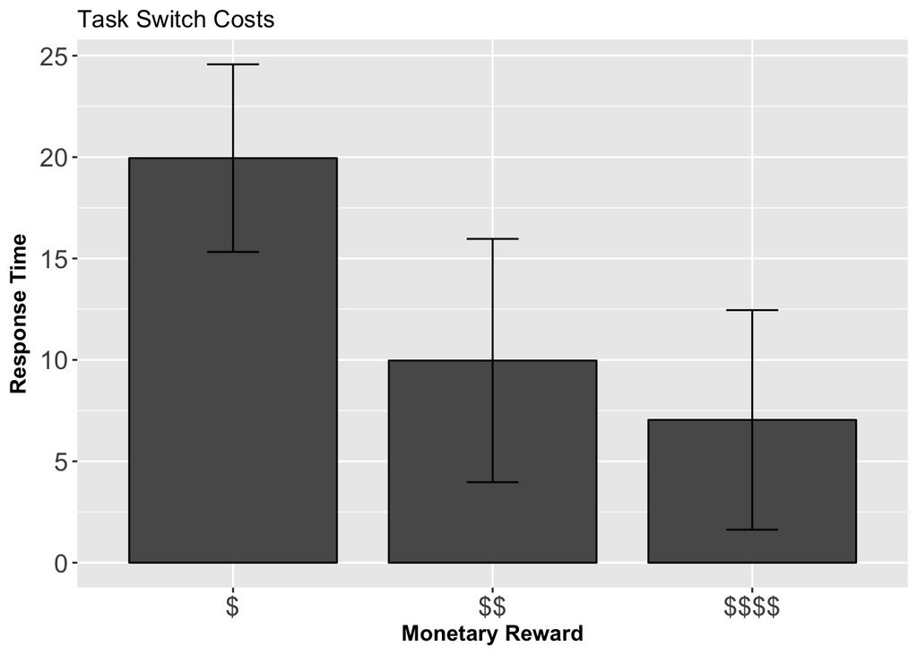

```r
p.switch.1<-ggplot(RT.sum, aes(x=money, y=meanRT)) +
  geom_bar(position=position_dodge(width=0.8), color="black",stat="identity", width=0.8) +
  geom_errorbar(position=position_dodge(width=0.8),
                aes(ymin=meanRT-se, ymax=meanRT+se), width=.2) +
  #facet_grid(.~money) +
  xlab("Monetary Reward") + ylab("Response Time") +
  ggtitle("Task Switch Costs") +
  #coord_cartesian(ylim=c(400,600)) +
  scale_fill_discrete(name="Task Switch") +
  theme(#plot.title=element_text(size=22,face="bold", vjust=2),
        axis.title=element_text(size=12,face = "bold"),
        axis.text=element_text(size=14),
        #legend.position="none",
        strip.text.x = element_text(size = 12))
p.switch.1
```

## Plotting the Switch Costs by Liquid

```r
data.switch<-incentive %>% group_by(subID,liquid,taskSwitch) %>%
  filter(!is.na(subRewarded),trial!=1) %>%
  summarise(meanRT=mean(RT)) %>%
  mutate(taskSwitch=factor(taskSwitch, levels=c(0,1), labels=c("taskrepeat","taskswitch"))) %>%
  spread(key = taskSwitch, value=meanRT) %>%
  mutate(meanRT=taskswitch-taskrepeat)

RT.sum=summarySEwithin2(data=data.switch, measurevar = "meanRT", withinvars = c("liquid"),
                        idvar = "subID")
pandoc.table(RT.sum)
```

```
##
## ----------------------------------------------------------------
##   liquid     N    meanRT   meanRTNormed    sd      se      ci
## ----------- ---- -------- -------------- ------- ------- -------
##    juice     39   13.37       13.37       35.54   5.691   11.52
##
##   neutral    39   16.63       16.63       32.06   5.133   10.39
##
##  saltwater   39   7.344       7.344       22.86   3.66    7.41
## ----------------------------------------------------------------
```

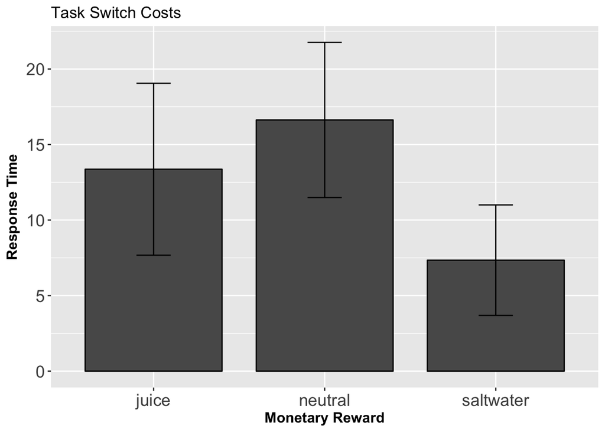

```r
p.switch.2<-ggplot(RT.sum, aes(x=liquid, y=meanRT)) +
  geom_bar(position=position_dodge(width=0.8), color="black",stat="identity", width=0.8) +
  geom_errorbar(position=position_dodge(width=0.8),
                aes(ymin=meanRT-se, ymax=meanRT+se), width=.2) +
  #facet_grid(.~money) +
  xlab("Monetary Reward") + ylab("Response Time") +
  ggtitle("Task Switch Costs") +
  #coord_cartesian(ylim=c(400,600)) +
  scale_fill_discrete(name="Task Switch") +
  theme(#plot.title=element_text(size=22,face="bold", vjust=2),
        axis.title=element_text(size=12,face = "bold"),
        axis.text=element_text(size=14),
        #legend.position="none",
        strip.text.x = element_text(size = 12))
p.switch.2
```

## GLMM on the Switch Costs

It appears that switch costs are modulated by task switches, monetary reward, as well as an tineraction between the two

```r
# Is Reward Rate predicted by task switches? yes.
m.switch.1<-glmer(formula = subRewarded ~ taskSwitch + (1|subID),
                   data = incentive, family = binomial)
summary(m.switch.1)
```

```
## Generalized linear mixed model fit by maximum likelihood (Laplace
##   Approximation) [glmerMod]
##  Family: binomial  ( logit )
## Formula: subRewarded ~ taskSwitch + (1 | subID)
##    Data: incentive
##
##      AIC      BIC   logLik deviance df.resid
##  13253.3  13275.3  -6623.7  13247.3    11229
##
## Scaled residuals:
##     Min      1Q  Median      3Q     Max
## -3.2182 -1.1042  0.5056  0.7198  1.1392
##
## Random effects:
##  Groups Name        Variance Std.Dev.
##  subID  (Intercept) 0.3824   0.6184
## Number of obs: 11232, groups:  subID, 39
##
## Fixed effects:
##             Estimate Std. Error z value Pr(>|z|)
## (Intercept)  0.96503    0.10373   9.303  < 2e-16 ***
## taskSwitch  -0.17908    0.04222  -4.242 2.22e-05 ***
## ---
## Signif. codes:  0 '***' 0.001 '**' 0.01 '*' 0.05 '.' 0.1 ' ' 1
##
## Correlation of Fixed Effects:
##            (Intr)
## taskSwitch -0.210
```

```r
#Full Model (money,liquid,task switch)
m.switch.2<-glmer(formula = subRewarded ~ taskSwitch*moneyCode*liqCode + (1+moneyCode+liqCode|subID),
                   data = incentive, family = binomial)
summary(m.switch.2)
```

```
## Generalized linear mixed model fit by maximum likelihood (Laplace
##   Approximation) [glmerMod]
##  Family: binomial  ( logit )
## Formula:
## subRewarded ~ taskSwitch * moneyCode * liqCode + (1 + moneyCode +
##     liqCode | subID)
##    Data: incentive
##
##      AIC      BIC   logLik deviance df.resid
##  13219.0  13321.6  -6595.5  13191.0    11218
##
## Scaled residuals:
##     Min      1Q  Median      3Q     Max
## -3.3875 -1.0691  0.4987  0.7052  1.3288
##
## Random effects:
##  Groups Name        Variance Std.Dev. Corr
##  subID  (Intercept) 0.388903 0.62362
##         moneyCode   0.006218 0.07885   0.08
##         liqCode     0.019069 0.13809  -0.22  0.45
## Number of obs: 11232, groups:  subID, 39
##
## Fixed effects:
##                               Estimate Std. Error z value Pr(>|z|)
## (Intercept)                   0.971050   0.104615   9.282  < 2e-16 ***
## taskSwitch                   -0.176227   0.042414  -4.155 3.25e-05 ***
## moneyCode                     0.089062   0.040042   2.224   0.0261 *
## liqCode                      -0.067031   0.044009  -1.523   0.1277
## taskSwitch:moneyCode          0.100396   0.051985   1.931   0.0535 .
## taskSwitch:liqCode           -0.032598   0.051974  -0.627   0.5305
## moneyCode:liqCode            -0.009129   0.045642  -0.200   0.8415
## taskSwitch:moneyCode:liqCode  0.100688   0.063692   1.581   0.1139
## ---
## Signif. codes:  0 '***' 0.001 '**' 0.01 '*' 0.05 '.' 0.1 ' ' 1
##
## Correlation of Fixed Effects:
##             (Intr) tskSwt monyCd liqCod tskSwtch:mC tskSwtch:lC mnyC:C
## taskSwitch  -0.209
## moneyCode    0.033 -0.016
## liqCode     -0.114  0.014  0.069
## tskSwtch:mC -0.005  0.034 -0.669  0.003
## tskSwtch:lC  0.005 -0.023  0.003 -0.609  0.005
## monyCd:lqCd -0.001  0.002 -0.024  0.024  0.017      -0.019
## tskSwtc:C:C  0.001  0.005  0.015 -0.014 -0.023       0.034      -0.715
```

```r
# Money and Task Switching
m.switch.3<-glmer(formula = subRewarded ~ taskSwitch*moneyCode + (1+moneyCode|subID),
                   data = incentive, family = binomial)
summary(m.switch.3)
```

```
## Generalized linear mixed model fit by maximum likelihood (Laplace
##   Approximation) [glmerMod]
##  Family: binomial  ( logit )
## Formula: subRewarded ~ taskSwitch * moneyCode + (1 + moneyCode | subID)
##    Data: incentive
##
##      AIC      BIC   logLik deviance df.resid
##  13227.5  13278.7  -6606.7  13213.5    11225
##
## Scaled residuals:
##     Min      1Q  Median      3Q     Max
## -3.3588 -1.0951  0.5041  0.7095  1.2461
##
## Random effects:
##  Groups Name        Variance Std.Dev. Corr
##  subID  (Intercept) 0.385673 0.62103
##         moneyCode   0.006321 0.07951  0.08
## Number of obs: 11232, groups:  subID, 39
##
## Fixed effects:
##                      Estimate Std. Error z value Pr(>|z|)
## (Intercept)           0.96743    0.10415   9.289   <2e-16 ***
## taskSwitch           -0.17664    0.04233  -4.173    3e-05 ***
## moneyCode             0.08854    0.04002   2.212   0.0269 *
## taskSwitch:moneyCode  0.10204    0.05187   1.967   0.0492 *
## ---
## Signif. codes:  0 '***' 0.001 '**' 0.01 '*' 0.05 '.' 0.1 ' ' 1
##
## Correlation of Fixed Effects:
##             (Intr) tskSwt monyCd
## taskSwitch  -0.209
## moneyCode    0.032 -0.016
## tskSwtch:mC -0.005  0.036 -0.668
```

# Generating Figures

## CNS 2018 Poster